# ipumsr - TCRUG

Greg Freedman Ellis

2/15/2018

# Using the ipums.org website

## Using the ipums.org website

- Live demo: www.ipums.org

## Using the ipums.org website

- www.ipums.org
- Choose a project (Example is USA)
- Register for an account
- Can select a subset of samples and variables to get only the parts that are relevant to your project. Example uses:
  - Default sample for 1960-2016 and variables
  - Variable: PHONE, EDUC and CONSPUMA
  - Select Cases (available when creating extract): Minnesota only

## Using the ipums.org website

- Interactively explore documentation while you choose
- Get alerted by email when it’s finished
- When ready, we’ll download the .dat file and the DDI.

# Setting up R

## Setting up R

- https://rstudio.cloud/project/18776
  - (slides also available at https://github.com/gergness/ipumsr-tcrug)
- Hopefully you can use rstudio.cloud to avoid any setup, but if you’d like to setup on your own machine, the slides below explain:

## Installing ipumsr

```r
install.packages("ipumsr")
```

- Or if you want the development version (which is what I’m using), use:

```r
if (!require(devtools)) install.packages("devtools")
devtools::install_github("mnpopcenter/ipumsr")
```

## Other packages

- Some of the examples below also rely on the development version of ggplot2 and a few extra packages.

```r
install.packages(c("shiny", "DT")) # For ipums_view()

install.packages("sf") # For the geography examples
devtools::install_github("tidyverse/ggplot2")

install.packages("revealjs") # For this presentation
```

# Loading data

## Setup R session

- Now that we’re all set up, we’ll use these libraries

```r
library(ipumsr)
library(dplyr)
library(ggplot2)
library(stringr)
library(sf)
```

## Loading data

- Using commands `read_ipums_ddi()` and `read_ipums_micro()`

```r
ddi <- read_ipums_ddi("usa_00013.xml")

data <- read_ipums_micro(ddi)
```

```
#> Use of data from IPUMS-USA is subject to conditions including that users should
#> cite the data appropriately. Use command `ipums_conditions()` for more details.
```

## Available metadata

- Some (but not all) of the documentation comes with the ddi.

```r
ipums_var_label(ddi, PHONE)
```

```
#> [1] "Telephone availability"
```

```r
ipums_var_desc(ddi, PHONE) %>% strwrap(60)
```

```
#> [1] "PHONE indicates whether residents of the housing unit had"
#> [2] "telephone access."
```

## Available metadata

```r
ipums_val_labels(ddi, PHONE)
```

```
#> # A tibble: 4 x 2
#>     val lbl
#>   <dbl> <chr>
#> 1    0. N/A
#> 2    1. No, no phone available
#> 3    2. Yes, phone available
#> 4    8. Suppressed (2012 and 2015 ACS)
```

## A nicer view of metadata

- `ipums_view()` makes a nicely formatted static html page for just your extract using htmltools.

```r
ipums_view(ddi)
```

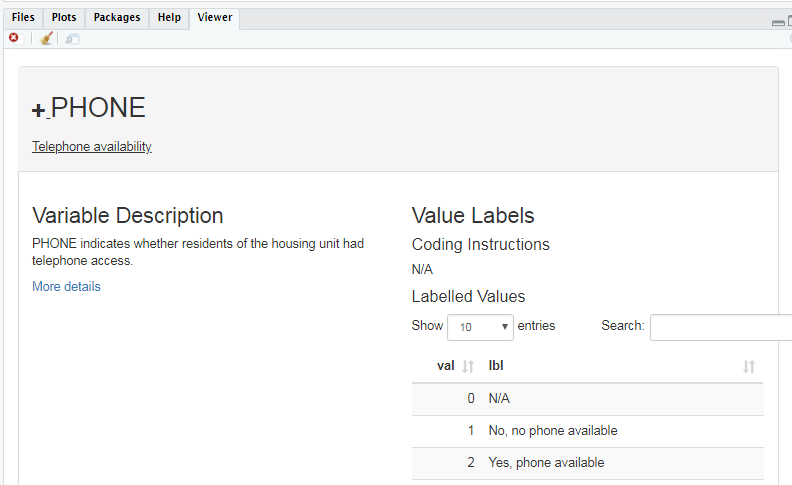

## Data

A regular `tbl_df` data.frame

```r
data
```

```
#> # A tibble: 1,476,443 x 12
#>     YEAR DATANUM  SERIAL  HHWT STATEFIP    CONSPUMA GQ          PHONE
#>    <int>   <dbl>   <dbl> <dbl> <int+lbl>      <dbl> <int+lbl>   <int+lbl>
#>  1  1960      1. 336455.  100. 27 [Minnes…       NA 1 [Househo… 2 [Yes, p…
#>  2  1960      1. 336455.  100. 27 [Minnes…       NA 1 [Househo… 2 [Yes, p…
#>  3  1960      1. 336456.  100. 27 [Minnes…       NA 1 [Househo… 2 [Yes, p…
#>  4  1960      1. 336456.  100. 27 [Minnes…       NA 1 [Househo… 2 [Yes, p…
#>  5  1960      1. 336456.  100. 27 [Minnes…       NA 1 [Househo… 2 [Yes, p…
#>  6  1960      1. 336456.  100. 27 [Minnes…       NA 1 [Househo… 2 [Yes, p…
#>  7  1960      1. 336457.   99. 27 [Minnes…       NA 1 [Househo… 2 [Yes, p…
#>  8  1960      1. 336457.   99. 27 [Minnes…       NA 1 [Househo… 2 [Yes, p…
#>  9  1960      1. 336457.   99. 27 [Minnes…       NA 1 [Househo… 2 [Yes, p…
#> 10  1960      1. 336458.  100. 27 [Minnes…       NA 1 [Househo… 2 [Yes, p…
#> # ... with 1,476,433 more rows, and 4 more variables: PERNUM <dbl>,
#> #   PERWT <dbl>, EDUC <int+lbl>, EDUCD <int+lbl>
```

# Wrangling value labels

## Wrangling value labels

- IPUMS value labels don’t translate that well to R’s factors.
  - (Factors always have a label, and always have values starting at 1)
- So `ipumsr` imports them as `haven::labelled()` objects, which aren’t always the easiest to deal with.
- Luckily ipumsr provides helpers that allow you to use information from both the value and label

## `as_factor()`

- `as_factor()` (from haven) converts directly to a factor.

```r
ipums_val_labels(data$GQ)
```

```
#> # A tibble: 7 x 2
#>     val lbl
#>   <dbl> <chr>
#> 1    0. Vacant unit
#> 2    1. Households under 1970 definition
#> 3    2. Additional households under 1990 definition
#> 4    3. Group quarters--Institutions
#> 5    4. Other group quarters
#> 6    5. Additional households under 2000 definition
#> 7    6. Fragment
```

## `as_factor()`

- Suppose we want to keep these labels exactly as they are.

```r
data$GQ2 <- as_factor(data$GQ)
```

| before ([val] label) | after | count |
| --- | --- | --- |
| [0] Vacant unit | Vacant unit | 0 |
| [1] Households under 1970 definition | Households under 1970 definition | 1433423 |
| [2] Additional households under 1990 definition | Additional households under 1990 definition | 1712 |
| [3] Group quarters--Institutions | Group quarters--Institutions | 19592 |
| [4] Other group quarters | Other group quarters | 21541 |
| [5] Additional households under 2000 definition | Additional households under 2000 definition | 175 |
| [6] Fragment | Fragment | 0 |

## `lbl_clean()`

- `lbl_clean()` gets rid of unused value labels.

```r
ipums_val_labels(data$STATEFIP)
```

```
#> # A tibble: 62 x 2
#>      val lbl
#>    <dbl> <chr>
#>  1    1. Alabama
#>  2    2. Alaska
#>  3    4. Arizona
#>  4    5. Arkansas
#>  5    6. California
#>  6    8. Colorado
#>  7    9. Connecticut
#>  8   10. Delaware
#>  9   11. District of Columbia
#> 10   12. Florida
#> # ... with 52 more rows
```

## `lbl_clean()`

- Since our extract only has Minnesota, we don’t want all of these values.

```r
data$STATEFIP2 <- data$STATEFIP %>%
  lbl_clean() %>%
  as_factor()
```

| before ([val] label) | after | count |
| --- | --- | --- |
| [27] Minnesota | Minnesota | 1476443 |

## `lbl_na_if()`

- `lbl_na_if()` allows you to set certain values or labels to missing.

```r
ipums_val_labels(data$PHONE)
```

```
#> # A tibble: 4 x 2
#>     val lbl
#>   <dbl> <chr>
#> 1    0. N/A
#> 2    1. No, no phone available
#> 3    2. Yes, phone available
#> 4    8. Suppressed (2012 and 2015 ACS)
```

## `lbl_na_if()`

- Easier to use R’s `NA` data structure to deal with missing values like “N/A” and “Suppressed”.

```r
data$PHONE2 <- lbl_na_if(data$PHONE, ~.val %in% c(0, 8)) %>%
  as_factor()
```

| before ([val] label) | after | count |
| --- | --- | --- |
| [0] N/A |  | 41133 |
| [1] No, no phone available | No, no phone available | 30852 |
| [2] Yes, phone available | Yes, phone available | 1404458 |
| [8] Suppressed (2012 and 2015 ACS) |  | 0 |

## `lbl_na_if()`

- It works with both values (`.val`) and labels (`.lbl`). So we could have also written something like this:

```r
drop_labels <- c("N/A", "Suppressed (2012 and 2015 ACS)")

data$PHONE3 <- lbl_na_if(data$PHONE, ~.lbl %in% drop_labels) %>%
  as_factor()
```

## `lbl_collapse()`

- `lbl_collapse()` allows you to take advantage of the hierarchical structure of value labels.

```r
ipums_val_labels(data$EDUCD)
```

```
#> # A tibble: 44 x 2
#>      val lbl
#>    <dbl> <chr>
#>  1    0. N/A or no schooling
#>  2    1. N/A
#>  3    2. No schooling completed
#>  4   10. Nursery school to grade 4
#>  5   11. Nursery school, preschool
#>  6   12. Kindergarten
#>  7   13. Grade 1, 2, 3, or 4
#>  8   14. Grade 1
#>  9   15. Grade 2
#> 10   16. Grade 3
#> # ... with 34 more rows
```

## `lbl_collapse()`

- Maybe this is too much detail, so we want to collapse the last digit.

```r
data$EDUCD2 <- lbl_collapse(data$EDUCD, ~.val %/% 10) %>%
  as_factor()
```

| before ([val] label) | after | count |
| --- | --- | --- |
| [0] N/A or no schooling | N/A or no schooling | 11811 |
| [1] N/A | N/A or no schooling | 50098 |
| [2] No schooling completed | N/A or no schooling | 50114 |
| [10] Nursery school to grade 4 | Nursery school to grade 4 | 40324 |
| [11] Nursery school, preschool | Nursery school to grade 4 | 14976 |
| [12] Kindergarten | Nursery school to grade 4 | 14611 |
| [13] Grade 1, 2, 3, or 4 | Nursery school to grade 4 | 15871 |
| [14] Grade 1 | Nursery school to grade 4 | 10715 |
| [15] Grade 2 | Nursery school to grade 4 | 11500 |
| [16] Grade 3 | Nursery school to grade 4 | 11836 |

[output cut: 34 more lines]

## `lbl_relabel()`

- `lbl_relabel()` has more granular control of what the values are assigned to.

```r
levels(data$EDUCD2)
```

```
#>  [1] "N/A or no schooling"       "Nursery school to grade 4"
#>  [3] "Grade 5, 6, 7, or 8"       "Grade 9"
#>  [5] "Grade 10"                  "Grade 11"
#>  [7] "Grade 12"                  "1 year of college"
#>  [9] "2 years of college"        "3 years of college"
#> [11] "4 years of college"        "5+ years of college"
#> [13] "Missing"
```

## `lbl_relabel()`

- Maybe the education variable is still too specific.

```r
data$EDUCD3 <- data$EDUCD %>%
  lbl_collapse(~.val %/% 10) %>%
  lbl_relabel(
    lbl(2, "Less than High School") ~.val > 0 & .val < 6,
    lbl(3, "High school") ~.lbl == "Grade 12",
    lbl(4, "Some college") ~str_detect(.lbl, "^[123] year(s)? of college$"),
    lbl(5, "College or more") ~.val %in% c(10, 11)
  ) %>%
  as_factor()
```

| before ([val] label) | after | count |
| --- | --- | --- |
| [0] N/A or no schooling | N/A or no schooling | 11811 |
| [1] N/A | N/A or no schooling | 50098 |
| [2] No schooling completed | N/A or no schooling | 50114 |
| [10] Nursery school to grade 4 | Less than High School | 40324 |
| [11] Nursery school, preschool | Less than High School | 14976 |
| [12] Kindergarten | Less than High School | 14611 |
| [13] Grade 1, 2, 3, or 4 | Less than High School | 15871 |
| [14] Grade 1 | Less than High School | 10715 |
| [15] Grade 2 | Less than High School | 11500 |
| [16] Grade 3 | Less than High School | 11836 |

[output cut: 34 more lines]

# Using data

## Phone availability

- Now that they’re factors, ready for use as regular R data

```r
graph_data <- data %>%
  group_by(YEAR) %>%
  summarize(`% with phone` = weighted.mean(
    PHONE2 == "Yes, phone available", PERWT, na.rm = TRUE
  ))

ggplot(graph_data, aes(x = YEAR, y = `% with phone`)) +
  geom_point() +
  geom_line() +
  labs(
    title = "Percent of Minnesota with phone line",
    subtitle = paste0("Data source: ", ddi$ipums_project),
    caption = paste(strwrap(ipums_var_desc(ddi, PHONE), 90), collapse = "\n")
  )
```

## Phone availability

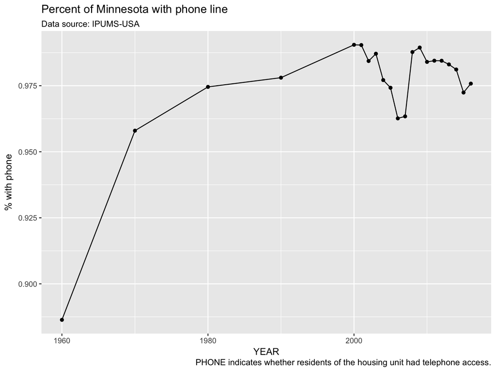

## Interpretation

> The 2008 ACS and 2008 PRCS instructed respondents to include cell phone service; prior to 2008, this was not made explicit.
> - https://usa.ipums.org/usa-action/variables/PHONE#comparability_section

## Phone availability by education

```r
graph_data <- data %>%
  group_by(YEAR, EDUCD3) %>%
  summarize(`% with phone` = weighted.mean(
    PHONE2 == "Yes, phone available", PERWT, na.rm = TRUE
  )) %>%
  ungroup()

ggplot(graph_data, aes(x = YEAR, y = `% with phone`)) +
  geom_point() +
  geom_line() +
  facet_wrap(~EDUCD3) +
  labs(
    title = "Percent of Minnesota with phone line by education",
    subtitle = paste0("Data source: ", ddi$ipums_project)
  )
```

## Phone availability by education

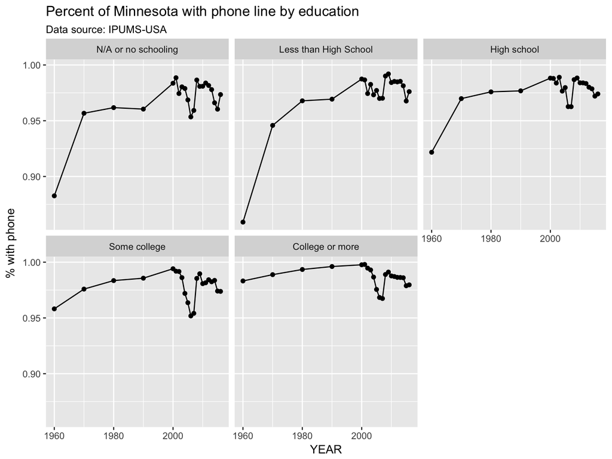

# Geographic data

## Getting geographic data

- For IPUMS USA (and several other projects), we provide geographic boundaries as well. For many areas, this includes harmonizing boundary changes over time.
- In our extract we included CONSPUMA, so let’s checkout the description on the website (https://usa.ipums.org/usa/volii/tgeotools.shtml) about it.
- Note that CONSPUMA is a rather large geography, if you want finer geographic detail, you need to hope that NHGIS has the table you want.

## Loading shape data

- `ipumsr` provides support for both sf and sp data, but I find the sf package much easier to use.
- To use, use the `ipums_read_sf()` function. (Mostly just a wrapper around `sf::read_sf`).

```r
shape_data <- read_ipums_sf("shape/")
```

```
#> options:        ENCODING=UTF-8
```

## Joining shape data

- We also provide helpers for merging data that work with both sf and sp packages.

```r
conspuma_data <- data %>%
  group_by(CONSPUMA, YEAR) %>%
  summarize(PHONE = weighted.mean(
    PHONE2 == "Yes, phone available", PERWT, na.rm = TRUE
  ))

conspuma_data <- ipums_shape_inner_join(
  conspuma_data,
  shape_data,
  by = "CONSPUMA"
)
```

```
#> Some observations were lost in the join (533 observations in the shape file and
#> 11 obervation in data). See `join_failures(...)` for more details.
```

## Plotting shape data

- With the development version of ggplot2, can plot sf data:

```r
graph_data <- conspuma_data %>%
  filter(YEAR %in% c(1980, 1990, 2000, 2010))

ggplot(graph_data, aes(fill = PHONE)) +
  facet_wrap(~YEAR) +
  geom_sf()
```

## Plotting shape data

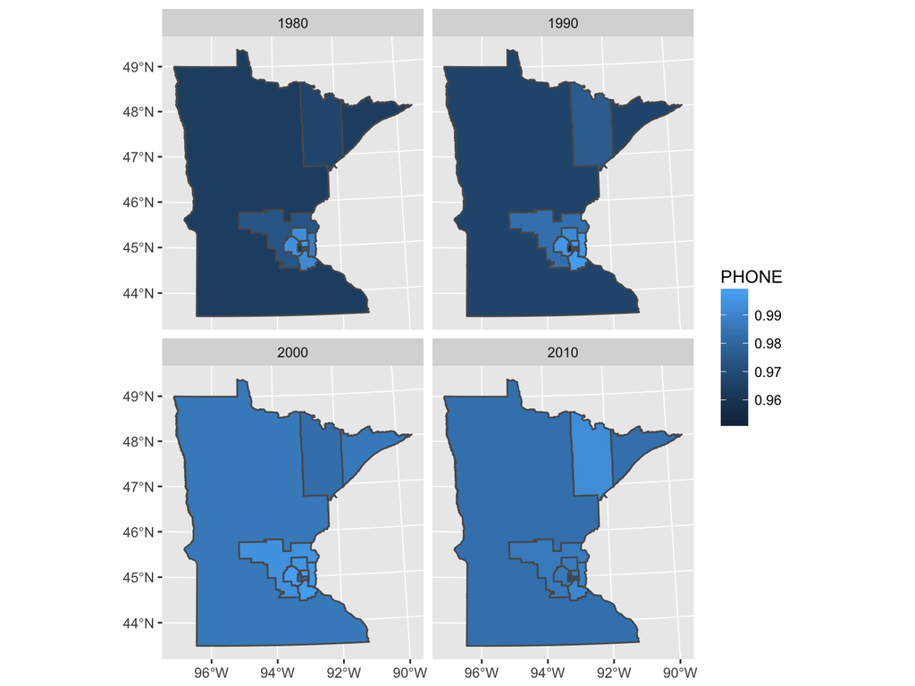

# Thanks!

## Thanks!

- Email: gfellis@umn.edu
- ipumsr github: https://github.com/mnpopcenter/ipumsr
- This presentation: https://rstudio.cloud/project/18776 / https://github.com/gergness/ipumsr-tcrug